# AS07_Web-Scraping-JSON

林綺薇 R09342000 新聞所碩一

2021/05/04

```r
library(tidyverse)
library(httr)
library(jsonlite)
options(stringsAsFactors = F)
```

## 作業目的: Web Scraping (01) JSON

這份作業希望能夠讓你熟悉 Web Scraping 的流程。

## 作業: Web Scraping (01) JSON

### 1. Scraping 104.com and Comparing salary:

我們在課程中爬取了104.com的工作列表，上面會有行業種類、工作場所和薪資等等。扣除「面議」的薪資不計，請嘗試爬取「資料科學」和「軟體工程」兩種職業的搜尋結果。請嘗試撰寫程式比較兩種職業的薪資差異。並用視覺化方式來表示兩種職業的差異。長條圖上應清楚顯示你所抓取的職業名稱。

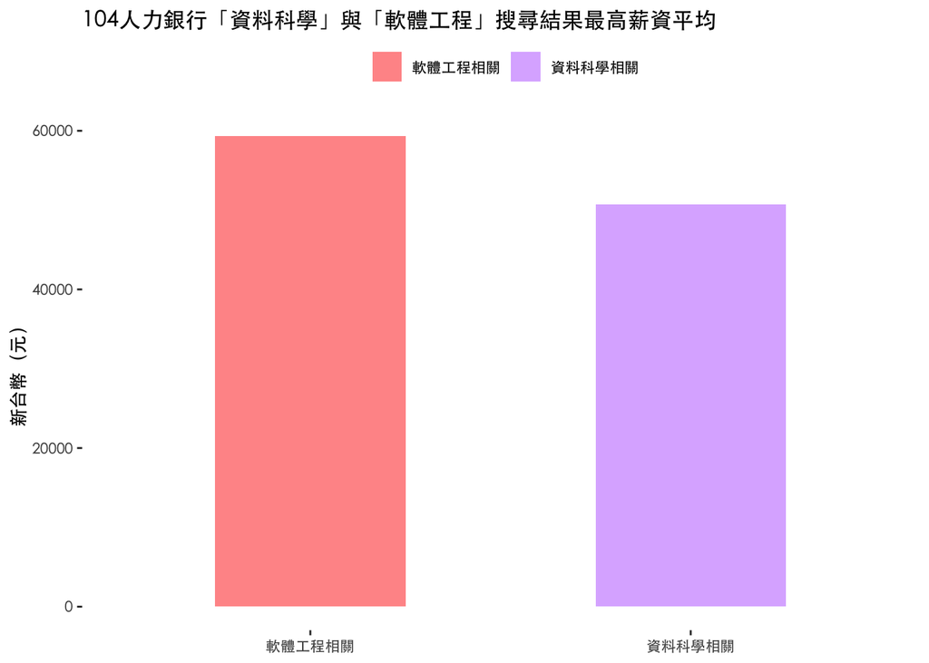

```r
### your code


url_1 <- "https://www.104.com.tw/jobs/search/list?ro=0&kwop=7&keyword=%E8%B3%87%E6%96%99%E7%A7%91%E5%AD%B8&expansionType=area%2Cspec%2Ccom%2Cjob%2Cwf%2Cwktm&order=12&asc=0&page=4&mode=s&jobsource=2018indexpoc"

refer_url <- "https://www.104.com.tw"

res_1 <- GET(url_1,add_headers("referer" = refer_url)) %>% content("text") %>%fromJSON()

res_1 <- res_1$data$list

res_1 <- res_1 %>%
  filter(!salaryDesc %in% c("待遇面議","時薪160元"),
         salaryHigh != "9999999") %>%
  select(salaryHigh) %>%
  mutate(salaryHigh = str_replace(salaryHigh, ".*?([1-9])", "\\1"),
         set = "資料科學相關",
         salaryHigh_mean = mean(as.numeric(salaryHigh))) %>%
  distinct(set,salaryHigh_mean)

url_2 <- "https://www.104.com.tw/jobs/search/list?ro=0&kwop=7&keyword=%E8%BB%9F%E9%AB%94%E5%B7%A5%E7%A8%8B&expansionType=area%2Cspec%2Ccom%2Cjob%2Cwf%2Cwktm&order=12&asc=0&page=4&mode=s&jobsource=2018indexpoc"

refer_url <- "https://www.104.com.tw"

res_2 <- GET(url_2,add_headers("referer" = refer_url)) %>% content("text") %>%fromJSON()

res_2 <- res_2$data$list

res_2 <- res_2 %>%
  filter(!salaryDesc %in% "待遇面議",
         salaryHigh != "9999999") %>%
  select(salaryHigh,salaryDesc) %>%
  mutate(salaryHigh = str_replace(salaryHigh, ".*?([1-9])", "\\1"),
         type = substring(salaryDesc,1,2),
         set = "軟體工程相關") %>%
  filter(type =="月薪") %>%
  mutate(salaryHigh_mean = mean(as.numeric(salaryHigh))) %>%
  distinct(set,salaryHigh_mean)

res_1 %>%
  bind_rows(res_2) %>%
  ggplot(aes(x = set , y = salaryHigh_mean ,width = 0.5 , fill = set)) +
  geom_col() +
  ylab("新台幣（元）")+
  xlab(NULL)+
  scale_fill_manual(values =c("#FF9797","#DCB5FF")) +
  theme_bw()+
  theme(text=element_text(family="黑體-繁 中黑", size=10),
        legend.title=element_blank(),
        legend.position = "top",
        panel.border = element_blank(),
        panel.grid.minor = element_blank(),
        panel.grid.major = element_blank())+
  labs(title = "104人力銀行「資料科學」與「軟體工程」搜尋結果最高薪資平均")
```

### 2. Scraping page with JSON data:

通常社群網站或者新聞網站都會有兩種頁面，一種是「文章列表」、另一種是每一則「文章內容」。我們在課程中示範了如何爬取104.com的工作列表，而且通常我可能只需要這樣的資料列表就可以做資料分析。但有時候你必須要把該列表裡的每一則文章內容給爬出來，才能夠近一步分析，如新聞網站或者DCard等。

請寫code以爬取鉅亨網的頭條新聞列表（https://news.cnyes.com/news/cat/headline?exp=a），或者爬取DCard某版貼文列表（如 https://www.dcard.tw/f/relationship?latest=true），請用for-loop至少爬取200則文章。

```r
### your code

all.df <- tibble()
refer_url <- "https://news.cnyes.com/"

for(p in 1:7){
  url <- str_c("https://api.cnyes.com/media/api/v1/newslist/category/headline?limit=30&startAt=1619280000&endAt=1620230399&page=",
            p)
  print(p)
  res <- GET(url,add_headers("referer" = refer_url)) %>% content("text") %>%fromJSON()

  res$items$data$newsId <- NULL
  res$items$data$hasCoverPhoto <- NULL
  res$items$data$isIndex<- NULL
  res$items$data$isCategoryHeadline <- NULL
  res$items$data$payment <- NULL
  res$items$data$publishAt <- NULL
  res$items$data$coverSrc <- NULL
  res$items$data$abTesting <- NULL
  res$items$data$categoryId <- NULL
  res$items$data$columnists <- NULL
  res$items$data$etf <- NULL
  res$items$data$fbShare <- NULL
  res$items$data$fbComment <- NULL
  res$items$data$fbCommentPluginCount <- NULL
  res$items$data$market <- NULL
  res$items$data$fundCategoryAbbr <- NULL
  res$items$data$status <- NULL
  res$items$data$video <- NULL

  all.df <- bind_rows(all.df,res$items$data)
  }


#all.df %>% select(content)%>% head(2) %>% pull()看某個東西的全文


nrow (all.df)
distinct(all.df)
```

```
#> [1] 1
#> [1] 2
#> [1] 3
#> [1] 4
#> [1] 5
#> [1] 6
#> [1] 7
#> [1] 210
#> # A tibble: 210 x 4
#>    title             content                 summary                categoryName
#>    <chr>             <chr>                   <chr>                  <chr>
#>  1 傳Archegos正準備聲請破產… "&lt;p&gt;韓籍避險基金經理 Bil… "韓籍避險基金經理 Bill Hwang … 美股
#>  2 禁言令不變！臉書裁決持續停權川普… "&lt;p&gt;臉書創辦人兼執行長祖克柏… "臉書獨立監督委員會週三 (5 日) 宣布… 美股
#>  3 特斯拉損失一收入來源！Stell… "&lt;p&gt;全球第四大車廠 Stel… "全球第四大車廠 Stellantis N… 美股
#>  4 〈美股早盤〉科技股領軍反彈 三大… "&lt;p&gt;在葉倫澄清提議升息的言論… "在葉倫澄清提議升息的言論後，科技股自昨日… 美股
#>  5 電動車及工業用需求佳 貿聯-KY… "&lt;p&gt;電動車及工業等需求帶動下… "在車用及工業等需求帶動下，連接線束廠貿聯… 台股新聞
#>  6 花旗撤13市場消金業務 華銀老董… "&lt;p&gt;在台耕耘近一甲子的花旗銀… "花旗出售台灣等 13 個市場消金業務，金… 台股新聞
#>  7 研華Q2營收估增3-7% 下半年… "&lt;p&gt;工業電腦大廠研華 (23… "工業電腦大廠研華 (2395-TW) 今… 台股新聞
#>  8 搶跨領域人才 英國保誠人壽招募儲… "&lt;p&gt;壽險業搶跨領域人才，英國… "壽險業搶跨領域人才，英國保誠人壽啟動第二… 台股新聞
#>  9 美國4月ADP小非農新增就業74… "&lt;p&gt;周三 (5 日) 公布美… "周三 (5 日) 公布美國 ADP 小非… 美股
#> 10 蔡明彰觀點：歐美疫情解封需求爆發… "&lt;p&gt;今天報告的主題是「歐美疫… ""                     台股新聞
#> # … with 200 more rows
```

### 3. 加分題:

前題僅能爬取鉅亨網和DCard的文章列表，但事實上他們每一則新聞或貼文也都是以JSON格式來儲存，請讀取剛剛你所爬取下來的貼文或新聞連結，把每一則新聞內容補完全。

```r
### your code

#第二題我已經抓到全文了，可以加分咪(ﾉ>ω<)ﾉ
```